# Analyzing the NYC Subway Dataset

### Section 0. Preparation

```python
import matplotlib
%matplotlib inline
#%matplotlib osx
import pandas
import numpy
from ggplot import *
import statsmodels.api as sm
import statsmodels
import scipy
import matplotlib.pyplot as plt
import math
import seaborn as sns
from datetime import datetime


df = pandas.read_csv('turnstile_data_master_with_weather.csv')
non_rain = df['ENTRIESn_hourly'][df['rain'] == 0]
rain = df['ENTRIESn_hourly'][df['rain'] == 1]
```

Before doing anything I want to have a look at data.

```python
df.describe()
```

|  | Unnamed: 0 | Hour | ENTRIESn_hourly | EXITSn_hourly | maxpressurei | maxdewpti | mindewpti | minpressurei | meandewpti | meanpressurei | fog | rain | meanwindspdi | mintempi | meantempi | maxtempi | precipi | thunder |
| --- | --- | --- | --- | --- | --- | --- | --- | --- | --- | --- | --- | --- | --- | --- | --- | --- | --- | --- |
| count | 131951.000000 | 131951.000000 | 131951.000000 | 131951.000000 | 131951.000000 | 131951.000000 | 131951.000000 | 131951.000000 | 131951.000000 | 131951.000000 | 131951.000000 | 131951.000000 | 131951.000000 | 131951.000000 | 131951.000000 | 131951.000000 | 131951.000000 | 131951 |
| mean | 65975.000000 | 10.896158 | 1095.348478 | 886.890838 | 30.031894 | 57.241302 | 48.259013 | 29.892714 | 52.703526 | 29.965077 | 0.167100 | 0.334245 | 5.543065 | 56.169775 | 64.269729 | 71.769968 | 0.172276 | 0 |
| std | 38091.117022 | 6.892084 | 2337.015421 | 2008.604886 | 0.125689 | 8.770891 | 11.305312 | 0.146384 | 9.943590 | 0.130461 | 0.373066 | 0.471728 | 1.982441 | 6.338875 | 6.568289 | 7.627218 | 0.429005 | 0 |
| min | 0.000000 | 0.000000 | 0.000000 | 0.000000 | 29.740000 | 39.000000 | 22.000000 | 29.540000 | 31.000000 | 29.640000 | 0.000000 | 0.000000 | 1.000000 | 46.000000 | 55.000000 | 58.000000 | 0.000000 | 0 |
| 25% | 32987.500000 | 5.000000 | 39.000000 | 32.000000 | 29.960000 | 50.000000 | 38.000000 | 29.840000 | 45.000000 | 29.910000 | 0.000000 | 0.000000 | 5.000000 | 52.000000 | 60.000000 | 65.000000 | 0.000000 | 0 |
| 50% | 65975.000000 | 12.000000 | 279.000000 | 232.000000 | 30.030000 | 57.000000 | 51.000000 | 29.910000 | 54.000000 | 29.960000 | 0.000000 | 0.000000 | 5.000000 | 54.000000 | 63.000000 | 71.000000 | 0.000000 | 0 |
| 75% | 98962.500000 | 17.000000 | 1109.000000 | 847.000000 | 30.100000 | 64.000000 | 55.000000 | 29.970000 | 60.000000 | 30.050000 | 0.000000 | 1.000000 | 6.000000 | 60.000000 | 68.000000 | 78.000000 | 0.100000 | 0 |
| max | 131950.000000 | 23.000000 | 51839.000000 | 45249.000000 | 30.310000 | 70.000000 | 66.000000 | 30.230000 | 68.000000 | 30.270000 | 1.000000 | 1.000000 | 12.000000 | 70.000000 | 78.000000 | 86.000000 | 2.180000 | 0 |

### Section 1. Statistical Test

The first question which I asked myself was: Is there any significant difference between number of people entering subway in rainy and non rainy days. As shown below, data for this particular question isn't normally distributed. So it's suitable to use non-parametric test. In class I've learnt Mann–Whitney U test. Null hypothesis for our two-sided test will be P(x>y)=0.5, where x - subway crowd in rainy days, y - subway crowd in non rainy days. At first let's check our assumptions about non-Gaussian data using Shapiro-Wilk test:

```python
scipy.stats.shapiro(rain)
```

```
(0.4715914726257324, 0.0)
```

```python
scipy.stats.shapiro(non_rain)
```

```
(0.47661787271499634, 0.0)
```

Personaly, I'm very sceptic and always want to confirm results using another approach. For second normality test I'll use scipy.stats.mstats.normaltest based on D'Agostino and Pearson's test (more information you can find in [docs.scipy.org](http://docs.scipy.org/doc/scipy-0.14.0/reference/generated/scipy.stats.mstats.normaltest.html). The method returns p-value for 2-sided chi-quared probability for the hypothesis test.

```python
scipy.stats.mstats.normaltest(rain)
```

```
(49379.024966302793, 0.0)
```

```python
scipy.stats.mstats.normaltest(non_rain)
```

```
(96614.17551121171, 0.0)
```

As we can see from Shapiro-Wilk and D'Agostino|Pearson test data is definitely non normal distributed due to extremely low p-value. Now let's calculate statistics and p-value for Mann Whitney U test ([wikipedia.org](http://en.wikipedia.org/wiki/Mann–Whitney_U_test)) and it's python implementation [scipy.stats](http://docs.scipy.org/doc/scipy-0.14.0/reference/generated/scipy.stats.mannwhitneyu.html):

```python
t, p_value = scipy.stats.mannwhitneyu(rain, non_rain)
2 * p_value
```

```
0.049999825586979442
```

We multiplied p-value by two in Mann Whitney U test, because scipy returns p-value for one-sided test. P-value is less than 0.05 - our significant level, so we should reject the null hypothesis about same mean Entries in rainy or not days. Let examine this data more and look at means and medians.

```python
"rain mean = {0}, non-rain mean = {1}".format(numpy.mean(rain), numpy.mean(non_rain))
```

```
'rain mean = 1105.44637675, non-rain mean = 1090.27878015'
```

```python
"rain median = {0}, non-rain median = {1}".format(numpy.median(rain), numpy.median(non_rain))
```

```
'rain median = 282.0, non-rain median = 278.0'
```

So it seems that statistical tests are right. In my opinion in shiny days people can walk on the street to work/university. But in rany days it's quite not comfortable, so maybe here is one of the differences. Also I should notice that I used significance level 5%.

### Section 2. Linear Regression

In my investigation of given dataset I was trying to predict how many people will enter subway using different predictors. I've used gradient descent and ols methods for this problem. I want to show prediction using ols method. Our response variable will be 'ENTRIESn_hourly'. Our predictiors will be 'EXITSn_hourly', 'rain', 'fog', 'meantempi'. Let's notice that rain and fog is our dummy variables. I decided to use fog and rain because I thought that when it is very foggy or rainy outside people might decide to use the subway more often. Also I decided to use hour variable because it increases R-squared value and maxtempi & meandewpti for their high variance.

```python
predictions = []
y = df['ENTRIESn_hourly']
x = df[['EXITSn_hourly' ,'rain', 'fog', 'meantempi', 'Hour', 'maxtempi','meandewpti']]
x = sm.add_constant(x)
model = sm.OLS(y,x)
results = model.fit()
results.summary()
```

OLS Regression Results

| Dep. Variable: | ENTRIESn_hourly | R-squared: | 0.558 |
| --- | --- | --- | --- |
| Model: | OLS | Adj. R-squared: | 0.558 |
| Method: | Least Squares | F-statistic: | 2.375e+04 |
| Date: | Fri, 16 Jan 2015 | Prob (F-statistic): | 0.00 |
| Time: | 05:32:05 | Log-Likelihood: | -1.1569e+06 |
| No. Observations: | 131951 | AIC: | 2.314e+06 |
| Df Residuals: | 131943 | BIC: | 2.314e+06 |
| Df Model: | 7 |  |  |
| Covariance Type: | nonrobust |  |  |

|  | coef | std err | t | P>\|t\| | [95.0% Conf. Int.] |
| --- | --- | --- | --- | --- | --- |
| const | 380.9771 | 47.154 | 8.079 | 0.000 | 288.556 473.398 |
| EXITSn_hourly | 0.8545 | 0.002 | 395.629 | 0.000 | 0.850 0.859 |
| rain | -35.4214 | 13.210 | -2.681 | 0.007 | -61.314 -9.529 |
| fog | 51.5961 | 13.148 | 3.924 | 0.000 | 25.826 77.366 |
| meantempi | -27.4049 | 3.948 | -6.941 | 0.000 | -35.143 -19.667 |
| Hour | 19.7976 | 0.629 | 31.475 | 0.000 | 18.565 21.030 |
| maxtempi | 17.8049 | 2.739 | 6.502 | 0.000 | 12.437 23.172 |
| meandewpti | 4.3164 | 1.067 | 4.045 | 0.000 | 2.225 6.408 |

| Omnibus: | 109669.538 | Durbin-Watson: | 1.504 |
| --- | --- | --- | --- |
| Prob(Omnibus): | 0.000 | Jarque-Bera (JB): | 25870638.598 |
| Skew: | 3.163 | Prob(JB): | 0.00 |
| Kurtosis: | 71.304 | Cond. No. | 2.44e+04 |

Coefficient of determination of our model is equal to 0.557. I want to remember that coefficient of determination has the following meaning - this is the percentage of variance that is explained by our model. We can see that our R-squared is too low to produce accurate predictions.

### Section 3. Visualization

Let's plot our ols prediction results. Let y-axis be 'ENTRIESn_hourly' and x-axis be 'EXITSn_hourly'. Plotting will be done using matplotlib.

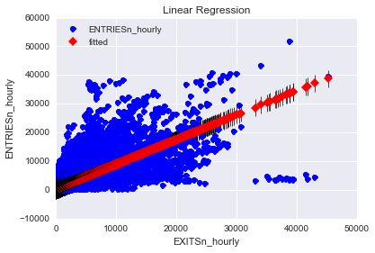

```python
fig, ax = plt.subplots()
statsmodels.graphics.regressionplots.plot_fit(results, 'EXITSn_hourly', ax=ax)
ax.set_ylabel("ENTRIESn_hourly")
ax.set_xlabel("EXITSn_hourly")
ax.set_title("Linear Regression")
plt.show()
```

As we can see from plot, we haven't got good model to predict ENTRIESn_hourly on each subway station. Let's create visualization which contains two histograms: one of ENTRIESn_hourly for rainy days and one of ENTRIESn_hourly for non-rainy days. For this visualization i've used ggplot.

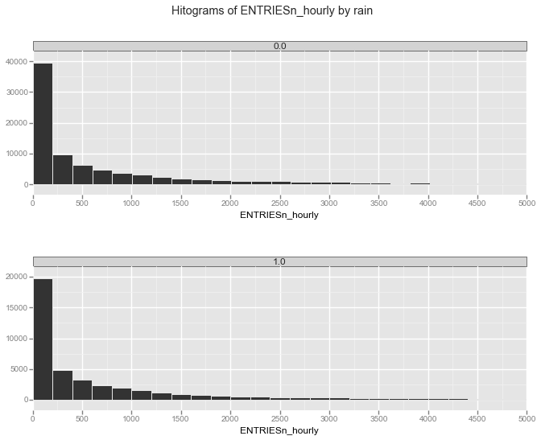

```python
ggplot(df, aes(x = 'ENTRIESn_hourly')) + geom_histogram(binwidth = 200) + facet_wrap('rain') + xlim(0,5000) +\
ggtitle("Hitograms of ENTRIESn_hourly by rain")
```

Let's add more plots and look at subway daily entries/exits with time.

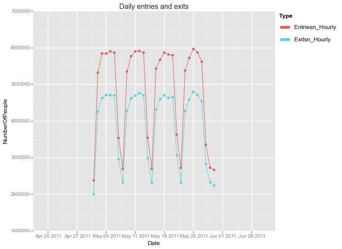

```python
df1 = df[['ENTRIESn_hourly', 'DATEn']].groupby('DATEn').sum()
df2 = df[['EXITSn_hourly', 'DATEn']].groupby('DATEn').sum()
df1.index.name = 'Date'
df1.reset_index(inplace=True)
df2.index.name = 'Date'
df2.reset_index(inplace=True)
df1.columns = ['Date', 'NumberOfPeople']
df2.columns = ['Date', 'NumberOfPeople']
df1['type'] = 'ENTRIESn_hourly'
df2['type'] = 'EXITSn_hourly'
total = pandas.concat([df1,df2])
total['Date'] = pandas.to_datetime(total['Date'])

ggplot(total, aes(x='Date', y='NumberOfPeople', color = 'type')) + geom_point() + geom_line() +\
ggtitle("Daily entries and exits")
```

Surprisingly, but I my thoughts are very different from this plot. I was thinking that summary number of Entries & Exits in subway should be near same value, but from plot we can see big difference between this two variables. Also it's very common that less people use subway in weekends.

The last one - let's create density plots of ENTRIESn_hourly depending on weather i.e. fog and rain As in class we will create fog-rain variable at first.

```python
def format_key(fog, rain):
    return '{}fog-{}rain'.format(
        '' if fog else 'no',
        '' if rain else 'no')

fograin = []
for index, row in df.iterrows():
    fograin.append(format_key(row['fog'], row['rain']))
df['fograin'] = pandas.Series(fograin)
```

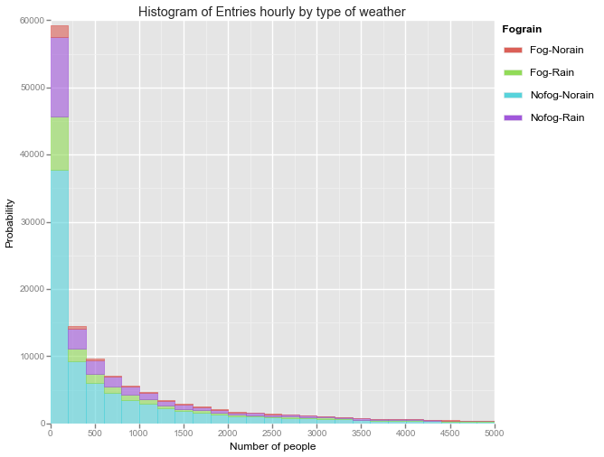

```python
ggplot(df, aes(x='ENTRIESn_hourly', fill='fograin', color='fograin')) + \
    geom_histogram(alpha=0.6, binwidth = 200) + xlim(0,5000) + \
    xlab("Number of people") + ylab("Probability") + ggtitle("Histogram of Entries hourly by type of weather")
```

From plot we can observe that mode of number of peoples in subway stay near the same. Also we can notice that our data is highly right skewed distributed.

### Section 4. Conclusion

At the end of conclusion I want to cite Mark Twain: "Lies, damned lies, and statistics". Who knows? OLS or Mann-Whitney U test? Personally I believe in Mann-Whitney U test, it's more specifically to answer question i'm asking in Section 1.

### Section 5. Reflection

I've found next potential shortcomings of dataset we use: 1. Daily entries aren't equal to daily exits. Is this a bug? Or maybe I just don't have clear understanding of EXITSn_hourly. I think that entries is how many people enter subway, exits - number of people exiting subway. I'm sure this variables should be daily equal. 2. Just one month of data. This implies low variablity of tempreture and other interesting features, so they might be not so important in May, but can be extremely useful in winter.

Some notes about application of Linear Regression to our dataset: 1. It's clear to see from figure that our data is seasonal. So we might include seasonal features to predict ENTRIESn_hourly. But classic linear regression doesn't take seasonality into account.

Last notes about statistical tests: 1. In my opinion for any test I should use at least two different approaches to calculate p-value for zero hypothesis. But actually i didn't find fully another approach of non parametric test for my task. Tests on data normality is more developed and i found a good amount of approaches for using in different situations.

P.S. All source code and ipython notebook can be found on [github](https://github.com/orenov/udacity-nanodegree-data-analyst/tree/master/Intro-to-Data-Science).